# Машинное обучение, ШАД

## Домашнее задание 4

**Правила:**

- Дедлайн **9 октября 15:00**. После дедлайна работы не принимаются кроме случаев наличия уважительной причины.
- Для сдачи задания нужно загрузить **ноутбук в формате `ipynb`** в ЛМС.
- Выполнять задание необходимо полностью самостоятельно.
- Для выполнения задания используйте этот ноутбук в качестве основы, ничего не удаляя из него. Можно добавлять необходимое количество ячеек.
- Комментарии к решению пишите в markdown-ячейках.
- Выполнение задания (ход решения, выводы и пр.) должно быть осуществлено на русском языке.
- Если код будет не понятен проверяющему, оценка может быть снижена.
- Никакой код из данного задания при проверке запускаться не будет. *Если код студента не выполнен, недописан и т.д., то он не оценивается.*

**Правила оформления теоретических задач:**

- Решения необходимо прислать одним из следующих способов:
  - фотографией в правильной ориентации, где все четко видно, а почерк разборчив,
    - прикрепив ее в ЛМС в форматах `pdf`, `png` или `jpg` *или*
    - вставив ее в ноутбук посредством `Edit -> Insert Image`;
  - в виде $\LaTeX$ в markdown-ячейках или в отдельном `pdf`-файле.
- Решения не проверяются, если какое-то требование не выполнено. Особенно внимательно все проверьте в случае выбора второго пункта (вставки фото в ноутбук). **Неправильно вставленные фотографии могут не передаться при отправке.** Для проверки попробуйте переместить `ipynb` в другую папку и открыть его там.
- В решениях поясняйте, чем вы пользуетесь, хотя бы кратко. Например, если пользуетесь независимостью, то достаточно подписи вида "*X и Y незав.*"
- Решение, в котором есть только ответ, и отсутствуют вычисления, оценивается в 0 баллов.

**Баллы за задание:**

- Задача 1 — 2 балла
- Задача 2 — 2 балла
- Задача 3 — 2 балла
- Задача 4 — 2 балла

### Задача 1.

> *В условии этой задачи подробно расписаны алгоритмы решения каждого пункта. Перед выполнением ознакомьтесь также с примерами, которые были рассказаны на лекции, они во многом аналогичны. При возникновении затруднений спрашивайте вопросы в чате.*

Пусть $X_1,...,X_n$ — выборка из экспоненциального распределения с плотностью $p_\theta(x) = \theta e^{-\theta x},$ где $x>0, \theta>0$. Такое распределение описывает время до наступления некоторого события. Например, таким событием может быть поступление очередного заказа таксисту или курьеру службы доставки. В таком случае $X_i$ — время ожидания $i$-го заказа после завершения предыдущего. Параметр $\theta$ имеет смысл интенсивности заказов в единицу времени. Следовательно, чем больше $\theta$, тем меньше среднее значение $X_i$. Точнее $\mathsf{E}_\theta X_i = 1/\theta$.

При выполнении задач используйте то, что $\mathsf{E}_\theta X_i^k = k!/\theta^k$.

**1.** Предложите асимптотически нормальную оценку $\theta$ и найдите ее асимптотическую дисперсию.

- Для выполнения этого пункта запишите центральную предельную теорему. Для какой функции $h(\theta)$ тем самым получилась асимптотически нормальная оценка?
- Какую функцию нужно применить, чтобы получить оценку для $\theta$?
- Воспользуйтесь дельта-методом, чтобы получить асимптотически нормальную оценку $\theta$. Не забудьте проверить применимость дельта-метода.
- Посчитайте ее асимптотическую дисперсию по формуле, которую дает дельта-метод. Обратите внимание, что в качестве аргумента производной нужно взять ту величину, для которой мы сначала построили оценку, то есть для $h(\theta)$.

**2.** А почему мы применяем центральную предельную теорему именно к такой выборке? Почему бы не применить ее к выборке $X_1^2,...,X_n^2$?

Сделайте это и получите еще одну асмптотически нормальную оценку $\theta$.

**3.** По каждой из двух асимптотически нормальных оценок $\theta$ постройте асимптотический доверительный интервал Вальда уровня доверия $\alpha$. Не забудьте в каждом случае заменить $\theta$ в асимптотической дисперсии на соответствующую оценку.

**4.** Мы построили два интервала. Какой из них лучше? Об этом мы узнаем в следующей задаче, а сейчас давайте построим еще и точный неасимптотический интервал. Известно, что $\overline{X}$ имеет гамма-распределение, воизбежании путаницы с параметрами сразу приведем для него строчку кода `scipy.stats.gamma(a=n, scale=1/(n*theta))`.

Чтобы построить интервал, выберите две квантили этого гамма-распределения и получите доверительный интервал аналогично тому, как мы это делали на занятии. Обратите внимание, гамма-распределение не симметрично, поэтому придется оставить обе квантили.

**5.** Используя полученные ранее асимптотически нормальные оценки постройте по ним критерии Вальда уровня значимости $1-\alpha$ для проверки гипотезы $\mathsf{H}_0\colon\theta = 1$. Обратите внимание, что для выполнения условия на вероятность ошибки первого рода (что она не больше $1-\alpha$) нам достаточно рассмотреть случай $\theta = 1$. Соответственно, используя асимптотически нормальную оценку вам нужно выписать статистику, которая при $\theta = 1$ сходится по распределению к $\mathcal{N}(0, 1)$. Далее ограничить ее квантилями и получить критерий.

**6.** Аналогичным образом постройте критерий, используя точное распределение $\overline{X}$ из пункта 4.

```python
import numpy as np
import pandas as pd
import scipy.stats as sps
from tqdm import tqdm
from functools import partial
import matplotlib.pyplot as plt
import seaborn as sns
sns.set(style='whitegrid', palette='Set2', font_scale=1.6)
```

```python
def draw_confidence_interval(
    left,
    right,
    estimation=None,
    sample=None,
    ylim=(None, None),
    color_estimation='#FF3300',
    color_interval='#00CC66',
    color_sample='#0066FF',
    label_estimation='',
    label_interval='',
):
    '''
    Рисует доверительный интервал и оценку в зависимости от размера выборки.

    :param left: левые границы интервалов (в зависимости от n)
    :param right: правые границы интервалов (в зависимости от n)
    :param estimation: оценки (в зависимости от n)
    :param sample: выборка
    :param ylim: ограничение вертикальной оси
    :param color_estimation: цвет оценки
    :param color_interval: цвет интервала
    :param color_sample: цвет выборки
    :param label_estimation: подпись для оценки
    :param label_interval: подпись для интервала
    '''

    time = np.arange(len(left)) + 1

    assert len(time) == len(right)

    if not sample is None:
        plt.scatter(time, sample, alpha=0.3, color=color_sample, s=40, label='Элемент выборки')
    if not estimation is None:
        plt.plot(time, estimation, color=color_estimation, linewidth=2.5, label=label_estimation)

    plt.fill_between(time, left, right, alpha=0.25, color=color_interval, label=label_interval)
    plt.legend()
    plt.ylim(ylim)
    plt.xlabel('Размер выборки')
    plt.title('Зависимость доверительного интервала от размера выборки')
```

```python
def calculate_confidence_interval(
    sample,
    type='asymptotic',
    alpha=0.95,
    return_estimation=False,
    cumulative=False,
    axis=-1,
):
    '''
    Вычисляет интервал Вальда по выборке.
    :param sample: Массив, содержащий выборки вдоль последней оси
    :param alpha: Уровень доверия
    :param return_estimation: Возвращать ли точечную оценку
    :param cumulative: Считать ли кумулятивные интервалы или только по всей выборке

    :return:
    Если return_estimation==False, то
        (left, right, estimation) - Границы интервалов
    Если return_estimation==True, то
        (left, right, estimation) - Границы интервалов и оценка
    '''

    if cumulative:
        sums = np.cumsum(sample, axis=axis)
        sums_sq = np.cumsum(sample**2, axis=axis)
        size = np.arange(sample.shape[axis]) + 1
    else:
        sums = np.sum(sample, axis=axis)
        sums_sq = np.sum(sample**2, axis=axis)


        size = sample.shape[axis]

    mean = sums / size
    var = sums_sq / size - mean**2

    if type == 'asymptotic':
        quantile_left = sps.norm.ppf((1 + alpha) / 2)
        quantile_right = sps.norm.ppf((1 + alpha) / 2)
        std = np.sqrt(var / size)
    elif type == 'exact':
        # quantile = sps.t.ppf((1 + alpha) / 2, df=size-1)
        # std = np.sqrt(var / (size-1))

        quantile_left = sps.chi2.ppf(alpha, df=size-1)
        quantile_right = sps.chi2.ppf(1 - alpha, df=size-1)

    # left = mean - quantile_left * std
    # right = mean + quantile_right * std

    left = (size - 1)*np.sqrt(var) / quantile_left
    right = (size - 1)*np.sqrt(var) / quantile_right

    if return_estimation:
        return left, right, mean
    else:
        return left, right


calculate_asymptotic_confidence_interval = partial(
    calculate_confidence_interval,
    type='asymptotic',
)
calculate_exact_confidence_interval = partial(
    calculate_confidence_interval,
    type='exact',
)
```

```python
max_sample_size = 30
#sample = np.random.normal(size=max_sample_size)  # выборка

n = 1 # замените на ваше значение
theta = 1  # замените на ваше значение
sample = sps.gamma.rvs(a=n, scale=1/(n*theta), size=max_sample_size)

alpha = 0.95  # уровень доверия
```

```python
left_asymptotic, right_asymptotic, mean = calculate_asymptotic_confidence_interval(
    sample,
    return_estimation=True,
    cumulative=True
)

left_exact, right_exact, mean = calculate_exact_confidence_interval(
    sample,
    return_estimation=True,
    cumulative=True
)
```

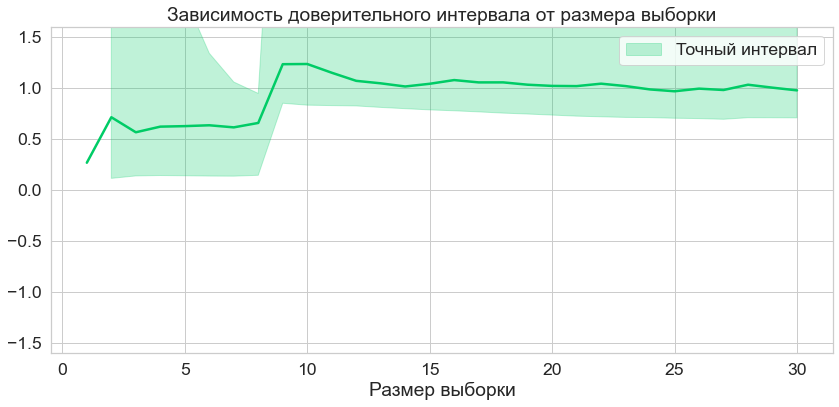

```python
plt.figure(figsize=(14, 6))

# draw_confidence_interval(
#     left_asymptotic,
#     right_asymptotic,
#     mean,
#     sample,
#     ylim=(None, None),
#     color_estimation='#00CC66',
#     color_interval='#FF3300',
#     label_estimation='$\\overline{X}$',
#     label_interval='Интервал Вальда',
# )

draw_confidence_interval(
    left_exact,
    right_exact,
    mean,
    ylim=(-1.6, 1.6),
    color_estimation='#00CC66',
    color_interval='#00CC66',
    label_interval='Точный интервал',
)
```